[figure not shown]

How to create applications  
using Shiny

ISGlobal

Barcelona, February 13-14th 2018

Part I: Introduction

### Outline

- **Part II:** Form design
  - Input elements
  - Output elements
  - Layout
  - Conditional panels
- **Part III:** Logic of Shiny
  - How Shiny works
  - Isolate
  - Reactive objects
  - Upload data
  - Download files
  - Rendering elements
- **Part IV:** Ways to improve the application
  - HTML and CSS
  - Pop-ups and Modals
  - Collapse panels
  - Carrouselles
  - Themes (app appearance)
  - Sizeable.
- **Part V:** Advanced issues
  - `observe` and `observeEvent` functions.
  - Updating elements
  - Reactive variables
  - `hide`, `show`, `toogle` and `disable` functions.

Introduction

### What is Shiny?

- [**Shiny**](http://shiny.rstudio.com/) in an [**R**](http://www.r-project.org/) package meant to build web based interactive apps.
- It has been created by [**RStudio**](http://www.rstudio.com/) team. (**Joe Chen**)
- No knowledgment of web lenguages such as **HTML**, **JavaScript** or **PHP** is required. It only uses **R** code.
- Very flexible and powerful apps can be designed by writting small pieces of code.
- Useful to make your R written functions or packages be used by many users not familiarized with R who prefers “click” than “type”.
- See [Shiny web page](http://shiny.rstudio.com/) with lots of examples and extensive help documents.

### Shiny website pages

[figure not shown]

[figure not shown]

[figure not shown]

[figure not shown]

### Shiny website examples

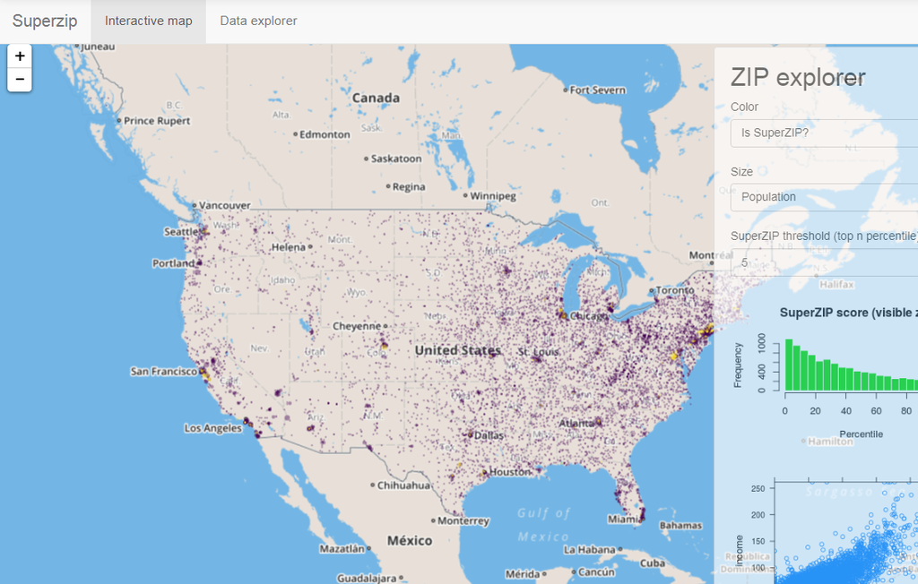

[figure not shown]

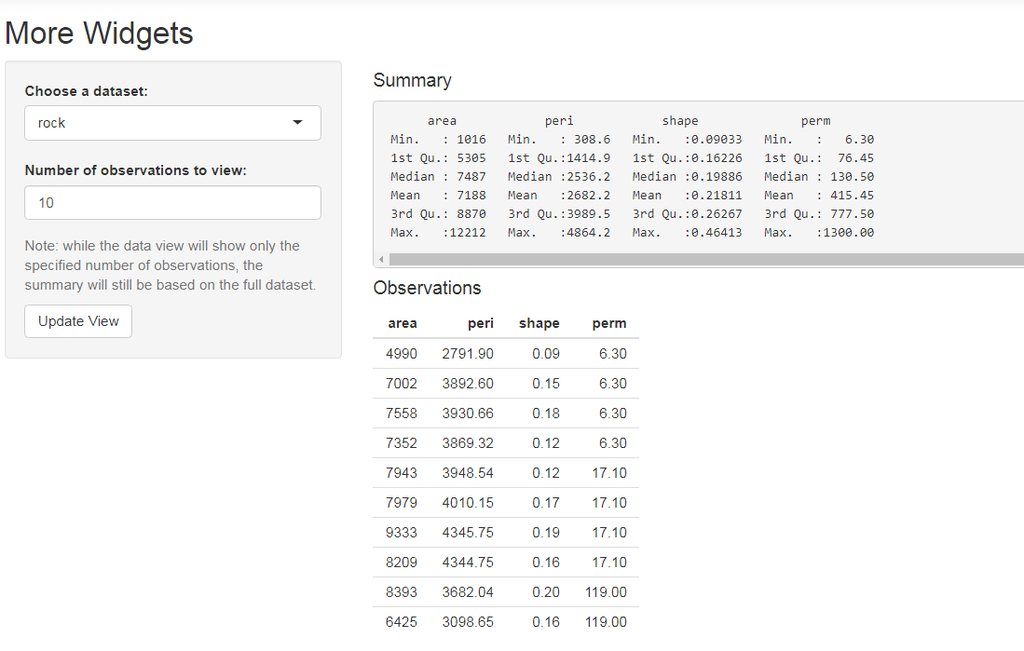

### R packages with Shiny-GUIs

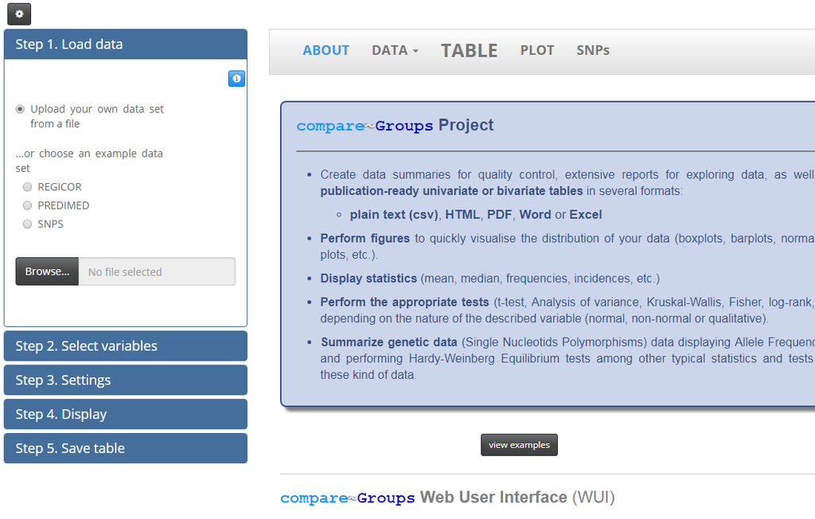

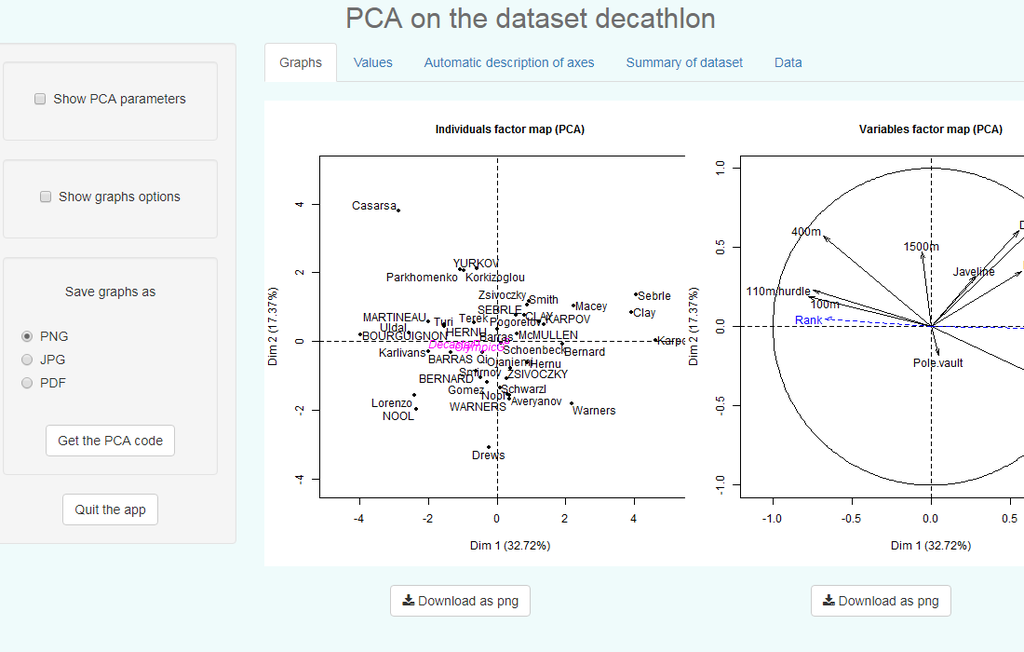

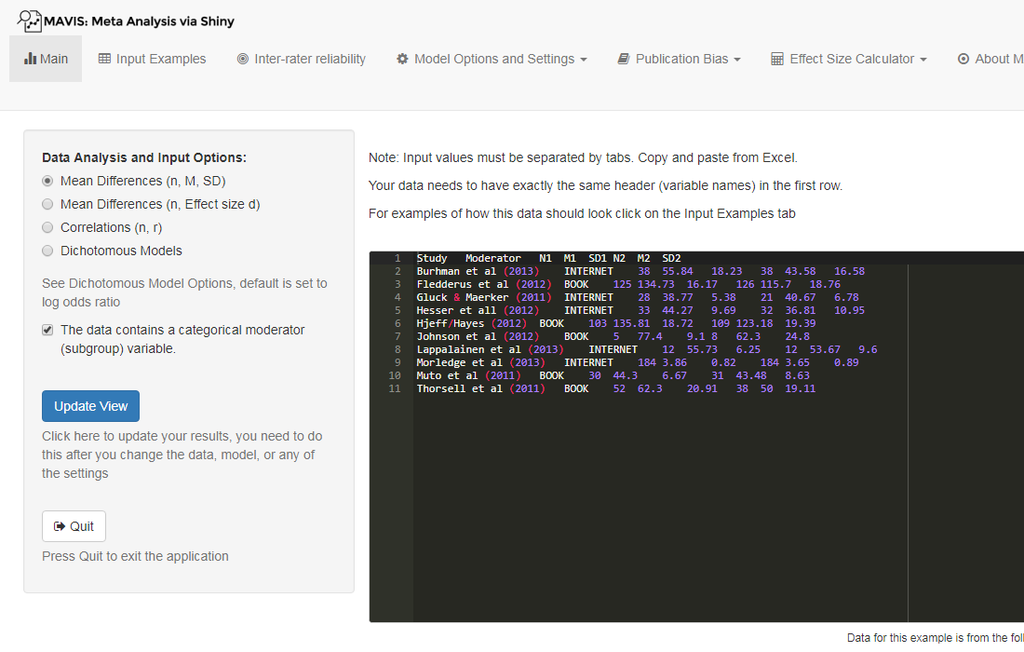

### How to use Shiny: (1) locally

**Requirements:**

**R** and **shiny** package must be installed in your PC or Mac.

**Steps**

1. Write the app code in two files named **“ui.R”** and **“server.R”** placed in the same folder.
2. Call `runApp()`.

**Alternative**

1. Write all code in a single file file named **app.R**.
2. call `runApp(list(ui, server))` or `shinyApp(ui, server)`.

### How to use Shiny: (2) remote server

**Own server**

- Advantages
  - Accessible from any device with internet explorer.
  - No need to have **R**, **shiny** or other packages/software.
- Requirements
  - **R**, **shiny** and other required packages/sofware installed in the server.
  - Install required software. More info [here](https://www.rstudio.com/products/shiny/download-server/).
  - OS must be Linux.

**Shiny server**

- Advantages
  - Very simple: only need to install `shinyapps` and registrer to www.shinyapps.io/.
  - Accessible from any device with internet explorer.
  - **Shiny server** offers use statistics.
- Inconveniences
  - Free up to a maximum number of hours and users.

### Shiny extensions: used in this course

Packages available on CRAN to improve both app appearance and functionality.

The ones we will see in the course:

- **`shinyBS`**: to create pop-ups, modals,… Visit its website [here](http://ebailey78.github.io/shinyBS/)
- **`bsplus`**: complementary to shinyBS. Also, it creates carrouselles. Visit its website [here](http://ijlyttle.github.io/bsplus/)
- **`shinyjs`**: to create toggles, hide or show elements, etc. Visit its website [here](http://daattali.com/shiny/shinyjs-demo/)
- **`shinyjqui`**: to make plots, tables, panels, etc. resizable. Visit its website [here](https://cran.r-project.org/web/packages/shinyjqui/vignettes/introduction.html)
- **`shinyFeedback`**: create alerts on input widgets when values out of range are introduced. Visit its website [here](https://cran.r-project.org/web/packages/shinyFeedback/vignettes/shinyFeedback-intro.html)
- **`shinythemes`**: change the app appearance. Visit its website [here](http://rstudio.github.io/shinythemes/)

### Shiny extensions: available on CRAN

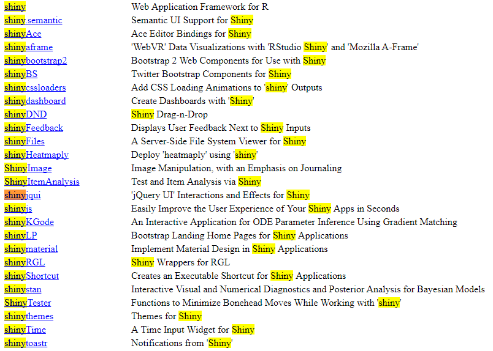

### "home" examples

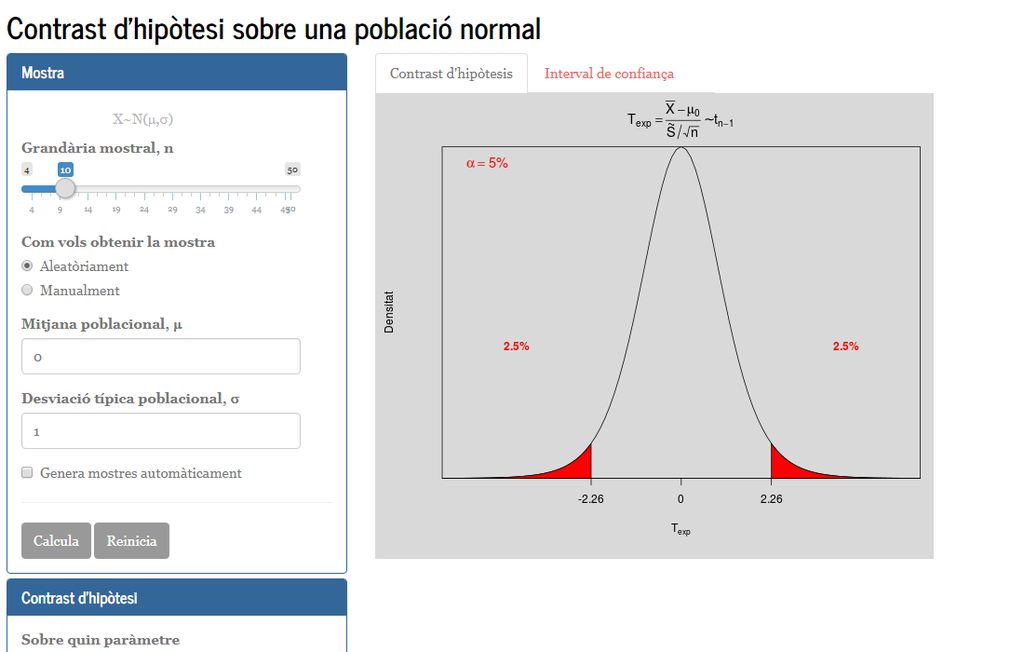

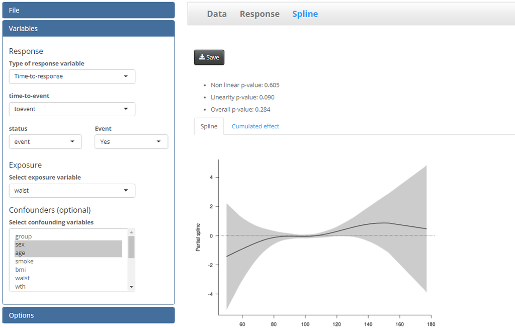

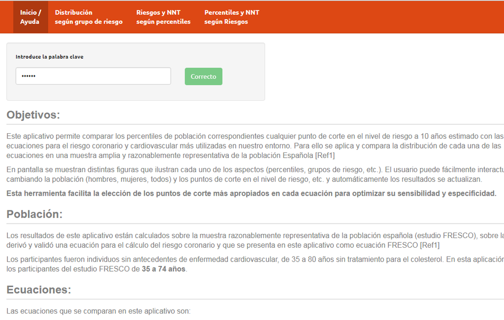

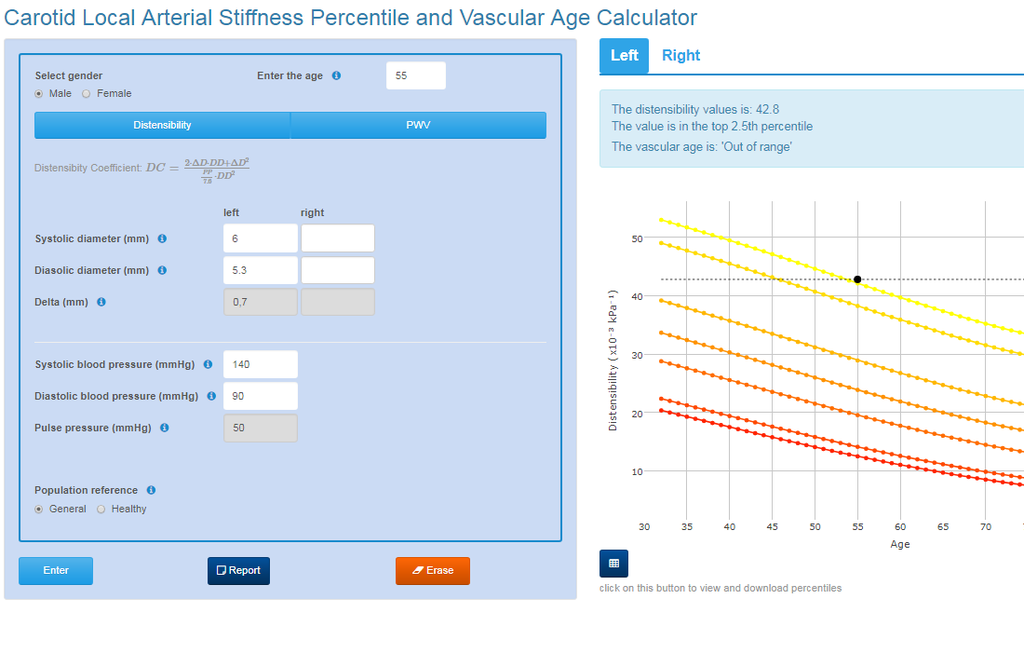

### My first app (RStudio)

[figure not shown]

[figure not shown]

[figure not shown]

[figure not shown]

[figure not shown]